# Machine Learning: Machin Learning from Titanic Disaster

### Section 1: Import Libraries/Dataset

#### Step 1: Import Libraries

```python
# Import Libraries
%matplotlib inline
import matplotlib.pyplot as plt
plt.style.use('seaborn-white')
import pandas as pd
import numpy as np
import seaborn as sns
from scipy.stats import boxcox
from sklearn.preprocessing import StandardScaler,PolynomialFeatures
from sklearn.ensemble import RandomForestClassifier,GradientBoostingClassifier
from sklearn.inspection import permutation_importance
from sklearn.model_selection import train_test_split
from sklearn.model_selection import KFold,cross_val_score,GridSearchCV
from sklearn.linear_model import LogisticRegression
from sklearn.metrics import accuracy_score, precision_score, recall_score, f1_score,classification_report
```

#### Step 2: Read Dataset and create dataframes.

```python
# Add .csv file in the required location. Read the data set and create required dataframes.
df = pd.read_csv('../data/train.csv')
```

### Section 2: Data Visualization and Exploration

#### Step 1: Print 20 rows for sanity check to identify all the features present in the dataset and if the target matches with them

```python
# we check the dataset with pandas head method, with just top 2 elements
df.head(20)
```

|  | PassengerId | Survived | Pclass | Name | Sex | Age | SibSp | Parch | Ticket | Fare | Cabin | Embarked |
| --- | --- | --- | --- | --- | --- | --- | --- | --- | --- | --- | --- | --- |
| 0 | 1 | 0 | 3 | Braund, Mr. Owen Harris | male | 22.0 | 1 | 0 | A/5 21171 | 7.2500 | NaN | S |
| 1 | 2 | 1 | 1 | Cumings, Mrs. John Bradley (Florence Briggs Th... | female | 38.0 | 1 | 0 | PC 17599 | 71.2833 | C85 | C |
| 2 | 3 | 1 | 3 | Heikkinen, Miss. Laina | female | 26.0 | 0 | 0 | STON/O2. 3101282 | 7.9250 | NaN | S |
| 3 | 4 | 1 | 1 | Futrelle, Mrs. Jacques Heath (Lily May Peel) | female | 35.0 | 1 | 0 | 113803 | 53.1000 | C123 | S |
| 4 | 5 | 0 | 3 | Allen, Mr. William Henry | male | 35.0 | 0 | 0 | 373450 | 8.0500 | NaN | S |
| 5 | 6 | 0 | 3 | Moran, Mr. James | male | NaN | 0 | 0 | 330877 | 8.4583 | NaN | Q |
| 6 | 7 | 0 | 1 | McCarthy, Mr. Timothy J | male | 54.0 | 0 | 0 | 17463 | 51.8625 | E46 | S |
| 7 | 8 | 0 | 3 | Palsson, Master. Gosta Leonard | male | 2.0 | 3 | 1 | 349909 | 21.0750 | NaN | S |
| 8 | 9 | 1 | 3 | Johnson, Mrs. Oscar W (Elisabeth Vilhelmina Berg) | female | 27.0 | 0 | 2 | 347742 | 11.1333 | NaN | S |
| 9 | 10 | 1 | 2 | Nasser, Mrs. Nicholas (Adele Achem) | female | 14.0 | 1 | 0 | 237736 | 30.0708 | NaN | C |
| 10 | 11 | 1 | 3 | Sandstrom, Miss. Marguerite Rut | female | 4.0 | 1 | 1 | PP 9549 | 16.7000 | G6 | S |
| 11 | 12 | 1 | 1 | Bonnell, Miss. Elizabeth | female | 58.0 | 0 | 0 | 113783 | 26.5500 | C103 | S |
| 12 | 13 | 0 | 3 | Saundercock, Mr. William Henry | male | 20.0 | 0 | 0 | A/5. 2151 | 8.0500 | NaN | S |
| 13 | 14 | 0 | 3 | Andersson, Mr. Anders Johan | male | 39.0 | 1 | 5 | 347082 | 31.2750 | NaN | S |
| 14 | 15 | 0 | 3 | Vestrom, Miss. Hulda Amanda Adolfina | female | 14.0 | 0 | 0 | 350406 | 7.8542 | NaN | S |
| 15 | 16 | 1 | 2 | Hewlett, Mrs. (Mary D Kingcome) | female | 55.0 | 0 | 0 | 248706 | 16.0000 | NaN | S |
| 16 | 17 | 0 | 3 | Rice, Master. Eugene | male | 2.0 | 4 | 1 | 382652 | 29.1250 | NaN | Q |
| 17 | 18 | 1 | 2 | Williams, Mr. Charles Eugene | male | NaN | 0 | 0 | 244373 | 13.0000 | NaN | S |
| 18 | 19 | 0 | 3 | Vander Planke, Mrs. Julius (Emelia Maria Vande... | female | 31.0 | 1 | 0 | 345763 | 18.0000 | NaN | S |
| 19 | 20 | 1 | 3 | Masselmani, Mrs. Fatima | female | NaN | 0 | 0 | 2649 | 7.2250 | NaN | C |

```python
# Provide basic info about the data and different features
df.info()
```

```
<class 'pandas.core.frame.DataFrame'>
RangeIndex: 891 entries, 0 to 890
Data columns (total 12 columns):
 #   Column       Non-Null Count  Dtype
---  ------       --------------  -----
 0   PassengerId  891 non-null    int64
 1   Survived     891 non-null    int64
 2   Pclass       891 non-null    int64
 3   Name         891 non-null    object
 4   Sex          891 non-null    object
 5   Age          714 non-null    float64
 6   SibSp        891 non-null    int64
 7   Parch        891 non-null    int64
 8   Ticket       891 non-null    object
 9   Fare         891 non-null    float64
 10  Cabin        204 non-null    object
 11  Embarked     889 non-null    object
dtypes: float64(2), int64(5), object(5)
memory usage: 83.7+ KB
```

```python
# Perform sanity check. Check for missing values if any.
df.isnull().sum()
```

```
PassengerId      0
Survived         0
Pclass           0
Name             0
Sex              0
Age            177
SibSp            0
Parch            0
Ticket           0
Fare             0
Cabin          687
Embarked         2
dtype: int64
```

```python
# Perform sanity check. Check for description of the data
df.describe()
```

|  | PassengerId | Survived | Pclass | Age | SibSp | Parch | Fare |
| --- | --- | --- | --- | --- | --- | --- | --- |
| count | 891.000000 | 891.000000 | 891.000000 | 714.000000 | 891.000000 | 891.000000 | 891.000000 |
| mean | 446.000000 | 0.383838 | 2.308642 | 29.699118 | 0.523008 | 0.381594 | 32.204208 |
| std | 257.353842 | 0.486592 | 0.836071 | 14.526497 | 1.102743 | 0.806057 | 49.693429 |
| min | 1.000000 | 0.000000 | 1.000000 | 0.420000 | 0.000000 | 0.000000 | 0.000000 |
| 25% | 223.500000 | 0.000000 | 2.000000 | 20.125000 | 0.000000 | 0.000000 | 7.910400 |
| 50% | 446.000000 | 0.000000 | 3.000000 | 28.000000 | 0.000000 | 0.000000 | 14.454200 |
| 75% | 668.500000 | 1.000000 | 3.000000 | 38.000000 | 1.000000 | 0.000000 | 31.000000 |
| max | 891.000000 | 1.000000 | 3.000000 | 80.000000 | 8.000000 | 6.000000 | 512.329200 |

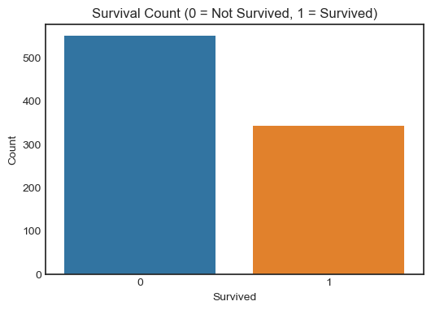

```python
# Count plot on the basis of survival
plt.figure(figsize=(6, 4))
sns.countplot(data=df, x='Survived')
plt.title("Survival Count (0 = Not Survived, 1 = Survived)")
plt.xlabel("Survived")
plt.ylabel("Count")
plt.show()
```

#### Step 3: Provide appropriate visualizations to get an insight about the dataset.

##### Age Distribution: Visualize the distribution of passenger age.

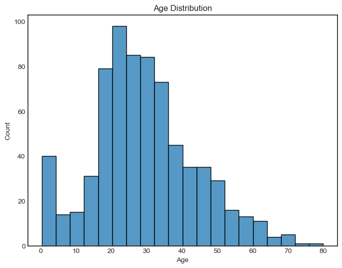

```python
plt.figure(figsize=(8, 6))
sns.histplot(data=df, x='Age', bins=20)
plt.title("Age Distribution")
plt.xlabel("Age")
plt.ylabel("Count")
plt.show()
```

##### Class wise Age Distribution: Visualize the distribution of passenger age by class.

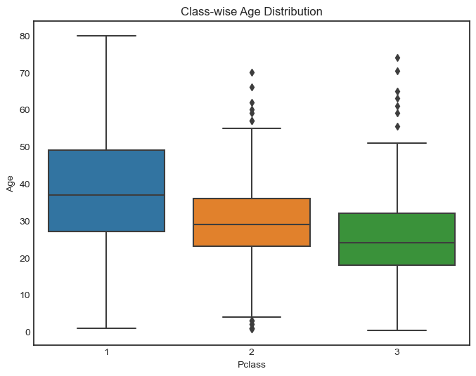

```python
plt.figure(figsize=(8, 6))
sns.boxplot(data=df, x='Pclass', y='Age')
plt.title("Class-wise Age Distribution")
plt.xlabel("Pclass")
plt.ylabel("Age")
plt.show()
```

##### Survival by gender: Visualize the distribution of survival of passenger by gender.

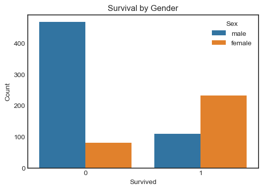

```python
plt.figure(figsize=(6, 4))
sns.countplot(data=df, x='Survived', hue='Sex')
plt.title("Survival by Gender")
plt.xlabel("Survived")
plt.ylabel("Count")
plt.legend(title="Sex")
plt.show()
```

##### Survival by passenger class: Visualize the distribution of survival of passenger by class.

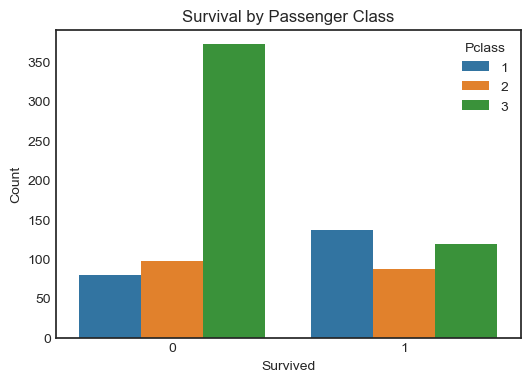

```python
plt.figure(figsize=(6, 4))
sns.countplot(data=df, x='Survived', hue='Pclass')
plt.title("Survival by Passenger Class")
plt.xlabel("Survived")
plt.ylabel("Count")
plt.legend(title="Pclass")
plt.show()
```

##### Survival by age groups: Visualize the distribution of survival of passenger by age group.

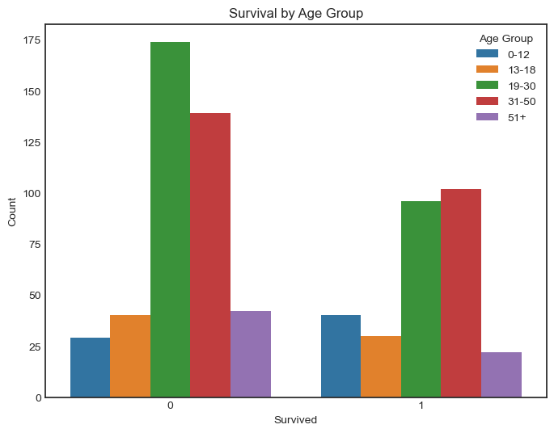

```python
plt.figure(figsize=(8, 6))
age_bins = [0, 12, 18, 30, 50, 100]
age_labels = ['0-12', '13-18', '19-30', '31-50', '51+']
df['AgeGroup'] = pd.cut(df['Age'], bins=age_bins, labels=age_labels)
sns.countplot(data=df, x='Survived', hue='AgeGroup')
plt.title("Survival by Age Group")
plt.xlabel("Survived")
plt.ylabel("Count")
plt.legend(title="Age Group")
plt.show()
```

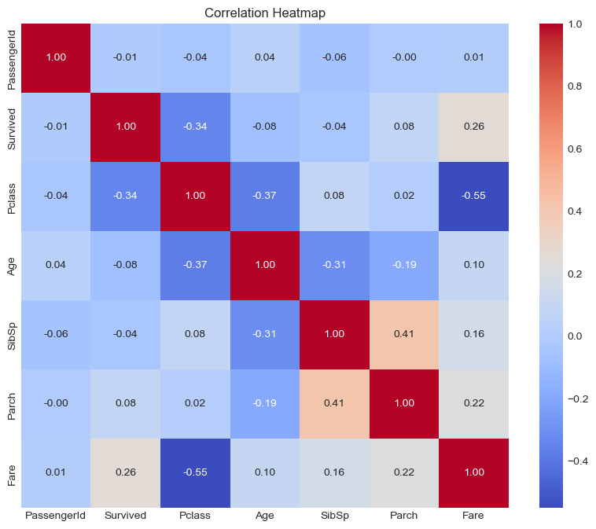

```python
correlation_matrix = df.corr()
# Create a heatmap for visualization
plt.figure(figsize=(10, 8))
sns.heatmap(correlation_matrix, annot=True, cmap='coolwarm', fmt=".2f")
plt.title("Correlation Heatmap")
plt.show()
```

#### Step 5: Any other visualisation specific to the problem statement

##### Fare distribution by survived class : Visualize the distribution of fares for passengers who survived and those who did not.

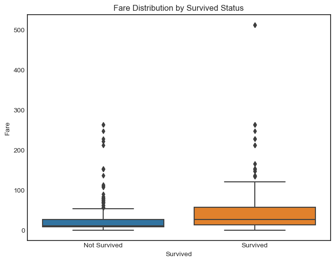

```python
plt.figure(figsize=(8, 6))
sns.boxplot(data=df, x='Survived', y='Fare')
plt.title("Fare Distribution by Survived Status")
plt.xlabel("Survived")
plt.ylabel("Fare")
plt.xticks([0, 1], ['Not Survived', 'Survived'])
plt.show()
```

##### Survival by embarkation port: Visualize the count of passengers who survived based on the embarkation port.

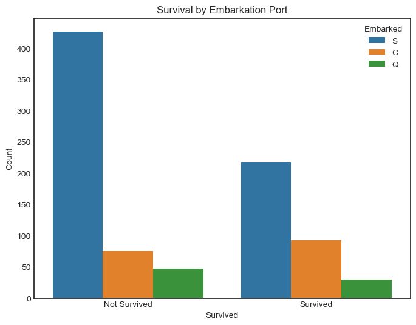

```python
plt.figure(figsize=(8, 6))
sns.countplot(data=df, x='Survived', hue='Embarked')
plt.title("Survival by Embarkation Port")
plt.xlabel("Survived")
plt.ylabel("Count")
plt.legend(title="Embarked")
plt.xticks([0, 1], ['Not Survived', 'Survived'])
plt.show()
```

##### Survival by family size : Visualize the survival count based on the family size (combined count of SibSp and Parch)

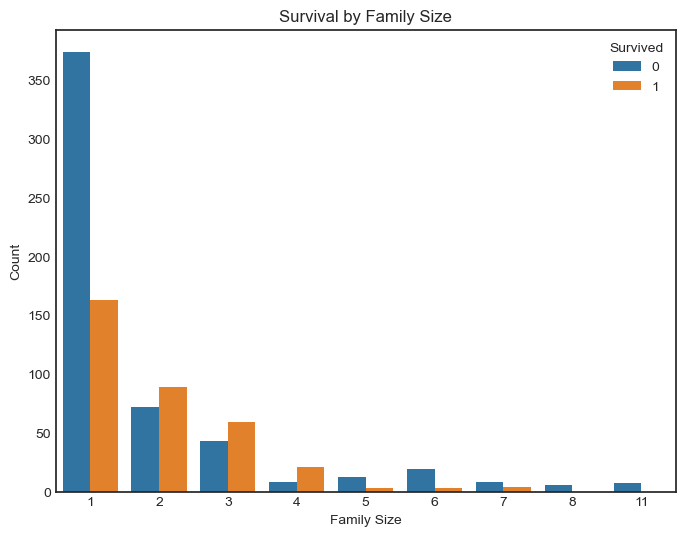

```python
df['FamilySize'] = df['SibSp'] + df['Parch'] + 1
plt.figure(figsize=(8, 6))
sns.countplot(data=df, x='FamilySize', hue='Survived')
plt.title("Survival by Family Size")
plt.xlabel("Family Size")
plt.ylabel("Count")
plt.legend(title="Survived")
plt.show()
```

##### Survival by gender and class: Visualize survival based on both gender and passenger class.

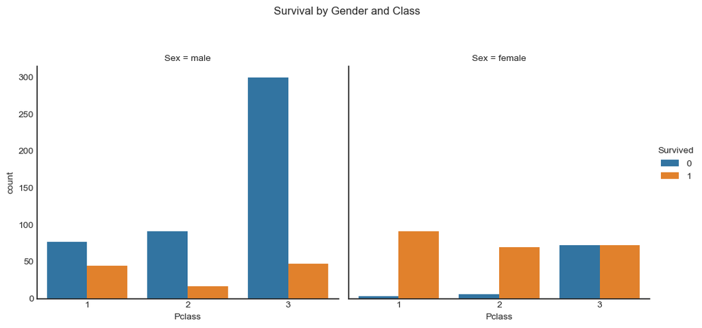

```python
plt.figure(figsize=(8, 6))
sns.catplot(data=df, x='Pclass', hue='Survived', col='Sex', kind='count')
plt.subplots_adjust(top=0.8)
plt.suptitle("Survival by Gender and Class")
plt.xlabel("Pclass")
plt.ylabel("Count")
plt.show()
```

### Section 3: Data Pre processing and cleaning

#### a. Identify Missing values

```python
# Identify missing values if any
df.isnull().sum()
```

```
PassengerId      0
Survived         0
Pclass           0
Name             0
Sex              0
Age            177
SibSp            0
Parch            0
Ticket           0
Fare             0
Cabin          687
Embarked         2
AgeGroup       177
FamilySize       0
dtype: int64
```

#### b. Handling Missing Values

```python
# Fill missing age with median values
median_age = df['Age'].median()
df["Age"].fillna(median_age,inplace=True)
```

```python
df.isnull().sum()
```

```
PassengerId      0
Survived         0
Pclass           0
Name             0
Sex              0
Age              0
SibSp            0
Parch            0
Ticket           0
Fare             0
Cabin          687
Embarked         2
AgeGroup       177
FamilySize       0
dtype: int64
```

```python
# Drop cabin column due to large number of missing values
df.drop(columns=['Cabin'], inplace=True)
df
```

|  | PassengerId | Survived | Pclass | Name | Sex | Age | SibSp | Parch | Ticket | Fare | Embarked | AgeGroup | FamilySize |
| --- | --- | --- | --- | --- | --- | --- | --- | --- | --- | --- | --- | --- | --- |
| 0 | 1 | 0 | 3 | Braund, Mr. Owen Harris | male | 22.0 | 1 | 0 | A/5 21171 | 7.2500 | S | 19-30 | 2 |
| 1 | 2 | 1 | 1 | Cumings, Mrs. John Bradley (Florence Briggs Th... | female | 38.0 | 1 | 0 | PC 17599 | 71.2833 | C | 31-50 | 2 |
| 2 | 3 | 1 | 3 | Heikkinen, Miss. Laina | female | 26.0 | 0 | 0 | STON/O2. 3101282 | 7.9250 | S | 19-30 | 1 |
| 3 | 4 | 1 | 1 | Futrelle, Mrs. Jacques Heath (Lily May Peel) | female | 35.0 | 1 | 0 | 113803 | 53.1000 | S | 31-50 | 2 |
| 4 | 5 | 0 | 3 | Allen, Mr. William Henry | male | 35.0 | 0 | 0 | 373450 | 8.0500 | S | 31-50 | 1 |
| ... | ... | ... | ... | ... | ... | ... | ... | ... | ... | ... | ... | ... | ... |
| 886 | 887 | 0 | 2 | Montvila, Rev. Juozas | male | 27.0 | 0 | 0 | 211536 | 13.0000 | S | 19-30 | 1 |
| 887 | 888 | 1 | 1 | Graham, Miss. Margaret Edith | female | 19.0 | 0 | 0 | 112053 | 30.0000 | S | 19-30 | 1 |
| 888 | 889 | 0 | 3 | Johnston, Miss. Catherine Helen "Carrie" | female | 28.0 | 1 | 2 | W./C. 6607 | 23.4500 | S | NaN | 4 |
| 889 | 890 | 1 | 1 | Behr, Mr. Karl Howell | male | 26.0 | 0 | 0 | 111369 | 30.0000 | C | 19-30 | 1 |
| 890 | 891 | 0 | 3 | Dooley, Mr. Patrick | male | 32.0 | 0 | 0 | 370376 | 7.7500 | Q | 31-50 | 1 |

891 rows × 13 columns

```python
df.isnull().sum()
```

```
PassengerId      0
Survived         0
Pclass           0
Name             0
Sex              0
Age              0
SibSp            0
Parch            0
Ticket           0
Fare             0
Embarked         2
AgeGroup       177
FamilySize       0
dtype: int64
```

```python
df.describe()
```

|  | PassengerId | Survived | Pclass | Age | SibSp | Parch | Fare | FamilySize |
| --- | --- | --- | --- | --- | --- | --- | --- | --- |
| count | 891.000000 | 891.000000 | 891.000000 | 891.000000 | 891.000000 | 891.000000 | 891.000000 | 891.000000 |
| mean | 446.000000 | 0.383838 | 2.308642 | 29.361582 | 0.523008 | 0.381594 | 32.204208 | 1.904602 |
| std | 257.353842 | 0.486592 | 0.836071 | 13.019697 | 1.102743 | 0.806057 | 49.693429 | 1.613459 |
| min | 1.000000 | 0.000000 | 1.000000 | 0.420000 | 0.000000 | 0.000000 | 0.000000 | 1.000000 |
| 25% | 223.500000 | 0.000000 | 2.000000 | 22.000000 | 0.000000 | 0.000000 | 7.910400 | 1.000000 |
| 50% | 446.000000 | 0.000000 | 3.000000 | 28.000000 | 0.000000 | 0.000000 | 14.454200 | 1.000000 |
| 75% | 668.500000 | 1.000000 | 3.000000 | 35.000000 | 1.000000 | 0.000000 | 31.000000 | 2.000000 |
| max | 891.000000 | 1.000000 | 3.000000 | 80.000000 | 8.000000 | 6.000000 | 512.329200 | 11.000000 |

```python
# Adding additional percentile to identify the right outliers quardrants
df.describe(percentiles=[0.10,0.25,0.50,0.75,0.80,0.90,0.95,0.995])
```

|  | PassengerId | Survived | Pclass | Age | SibSp | Parch | Fare | FamilySize |
| --- | --- | --- | --- | --- | --- | --- | --- | --- |
| count | 891.000000 | 891.000000 | 891.000000 | 891.000000 | 891.000000 | 891.000000 | 891.000000 | 891.000000 |
| mean | 446.000000 | 0.383838 | 2.308642 | 29.361582 | 0.523008 | 0.381594 | 32.204208 | 1.904602 |
| std | 257.353842 | 0.486592 | 0.836071 | 13.019697 | 1.102743 | 0.806057 | 49.693429 | 1.613459 |
| min | 1.000000 | 0.000000 | 1.000000 | 0.420000 | 0.000000 | 0.000000 | 0.000000 | 1.000000 |
| 10% | 90.000000 | 0.000000 | 1.000000 | 16.000000 | 0.000000 | 0.000000 | 7.550000 | 1.000000 |
| 25% | 223.500000 | 0.000000 | 2.000000 | 22.000000 | 0.000000 | 0.000000 | 7.910400 | 1.000000 |
| 50% | 446.000000 | 0.000000 | 3.000000 | 28.000000 | 0.000000 | 0.000000 | 14.454200 | 1.000000 |
| 75% | 668.500000 | 1.000000 | 3.000000 | 35.000000 | 1.000000 | 0.000000 | 31.000000 | 2.000000 |
| 80% | 713.000000 | 1.000000 | 3.000000 | 38.000000 | 1.000000 | 1.000000 | 39.687500 | 3.000000 |
| 90% | 802.000000 | 1.000000 | 3.000000 | 47.000000 | 1.000000 | 2.000000 | 77.958300 | 4.000000 |
| 95% | 846.500000 | 1.000000 | 3.000000 | 54.000000 | 3.000000 | 2.000000 | 112.079150 | 6.000000 |
| 99.5% | 886.550000 | 1.000000 | 3.000000 | 70.275000 | 8.000000 | 5.000000 | 263.000000 | 11.000000 |
| max | 891.000000 | 1.000000 | 3.000000 | 80.000000 | 8.000000 | 6.000000 | 512.329200 | 11.000000 |

#### c. Handling Outliers

```python
# Handling outliers
# Calculate IQR for 'Age' and 'Fare'
Q1 = df[['Age', 'Fare']].quantile(0.25)
Q3 = df[['Age', 'Fare']].quantile(0.75)
IQR = Q3 - Q1
```

```python
# Define lower and upper bounds for outlier detection
lower_bound = Q1 - 1.5 * IQR
upper_bound = Q3 + 1.5 * IQR
```

```python
lower_bound
```

```
Age      2.500
Fare   -26.724
dtype: float64
```

```python
upper_bound
```

```
Age     54.5000
Fare    65.6344
dtype: float64
```

```python
# Replace outliers with NaN in 'Age' column
df['Age'] = np.where((df['Age'] < lower_bound['Age']) | (df['Age'] > upper_bound['Age']), np.nan, df['Age'])
```

```python
# Replace outliers with NaN in 'Fare' column
df['Fare'] = np.where((df['Fare'] < lower_bound['Fare']) | (df['Fare'] > upper_bound['Fare']), np.nan, df['Fare'])
```

```python
# Handle missing values in 'Age' column using median
median_age = df['Age'].median()
df['Age'].fillna(median_age, inplace=True)
```

```python
# Handle missing values in 'Fare' column using median
median_fare = df['Fare'].median()
df['Fare'].fillna(median_fare, inplace=True)
```

#### d. Handling Skewness

```python
# Handling skewness in the data
# Apply Box-Cox transformation to 'Fare' column
df['Fare'] = df['Fare'].apply(lambda x: x + 1)  # Adding 1 to handle zero values
df['Fare'], _ = boxcox(df['Fare']) # Applying Box-Cox transformation
```

```python
# Apply log transformation to 'Age' column
df['Age'] = np.log1p(df['Age'])
```

#### e. Perform Encoding of Categorical Variables

```python
# Perform One-Hot Encoding for 'Sex' and 'Embarked' columns
encoded_df = pd.get_dummies(df, columns=['Sex', 'Embarked'], drop_first=True)
```

#### f. Visualizations post data pre processing

[figure not shown]

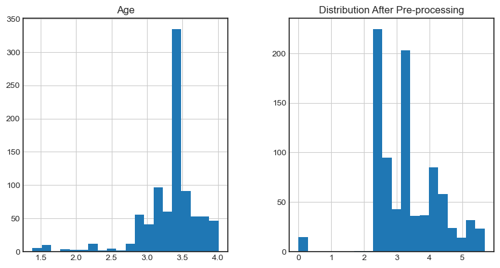

```python
# Before pre-processing
df[['Age', 'Fare']].hist(bins=20, figsize=(10, 5))
plt.title('Distribution Before Pre-processing')
plt.show()

# After pre-processing
encoded_df[['Age', 'Fare']].hist(bins=20, figsize=(10, 5))
plt.title('Distribution After Pre-processing')
plt.show()
```

##### 2. Pair Plot: Visualize relationships between numerical features using a pair plot.

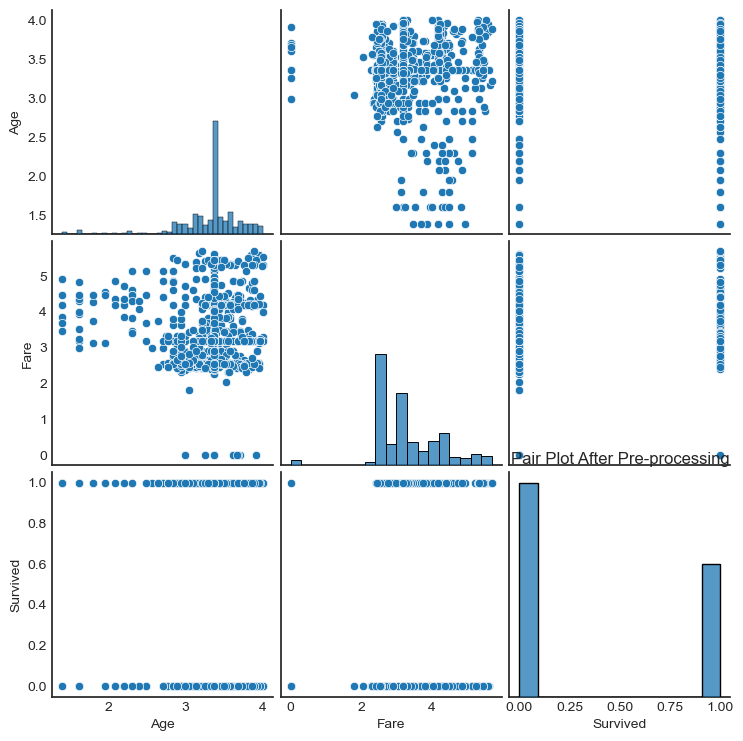

```python
sns.pairplot(encoded_df[['Age', 'Fare', 'Survived']])
plt.title('Pair Plot After Pre-processing')
plt.show()
```

##### 3. Correlation Heatmap: Visualize the correlation between numerical features.

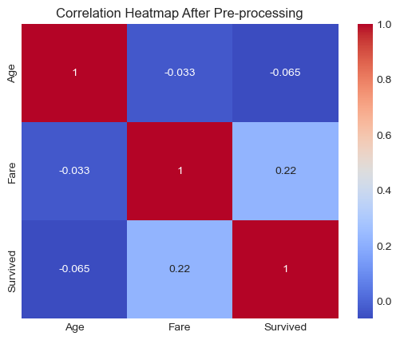

```python
correlation_matrix = encoded_df[['Age', 'Fare', 'Survived']].corr()
sns.heatmap(correlation_matrix, annot=True, cmap='coolwarm')
plt.title('Correlation Heatmap After Pre-processing')
plt.show()
```

##### 4. Count Plot: Visualize the distribution of categorical variables (e.g., 'Pclass', 'Sex_male', 'Embarked_Q','Embarked_S') after encoding.

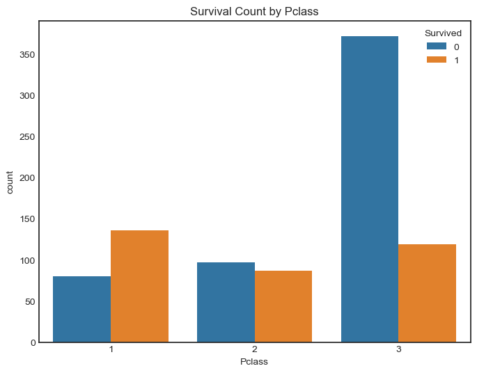

```python
plt.figure(figsize=(8, 6))
sns.countplot(x='Pclass', hue='Survived', data=encoded_df)
plt.title('Survival Count by Pclass')
plt.show()
```

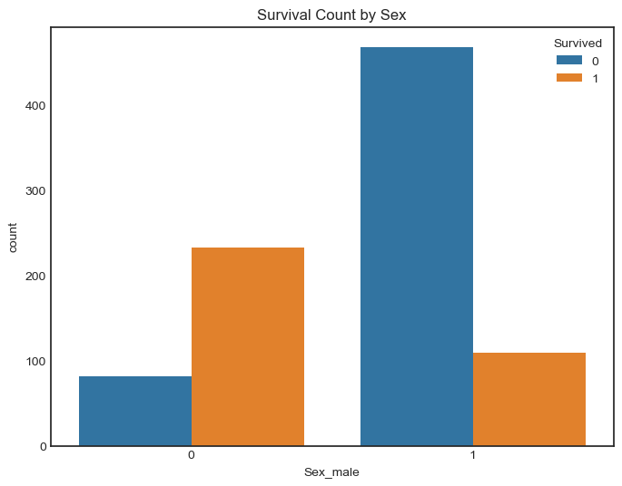

```python
plt.figure(figsize=(8, 6))
sns.countplot(x='Sex_male', hue='Survived', data=encoded_df)
plt.title('Survival Count by Sex')
plt.show()
```

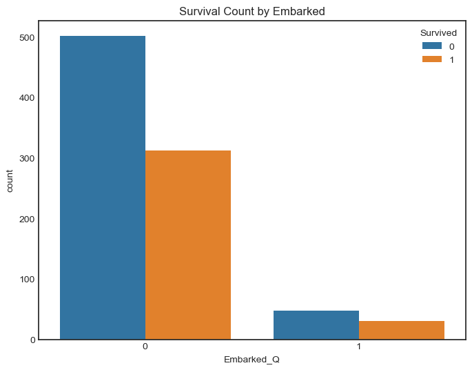

```python
plt.figure(figsize=(8, 6))
sns.countplot(x='Embarked_Q', hue='Survived', data=encoded_df)
plt.title('Survival Count by Embarked')
plt.show()
```

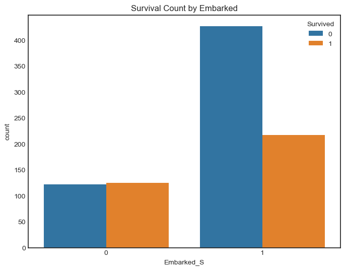

```python
plt.figure(figsize=(8, 6))
sns.countplot(x='Embarked_S', hue='Survived', data=encoded_df)
plt.title('Survival Count by Embarked')
plt.show()
```

##### 5. Box Plots: Visualize the spread of numerical features and their relationship with categorical variables.

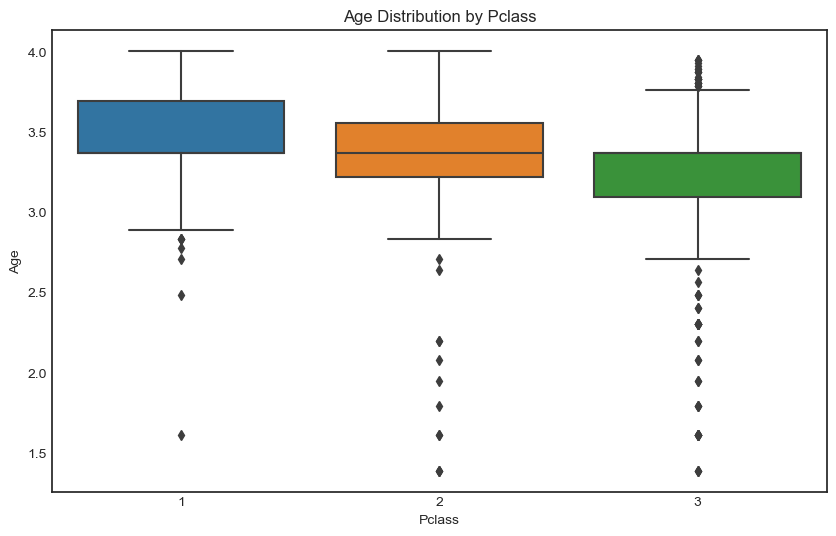

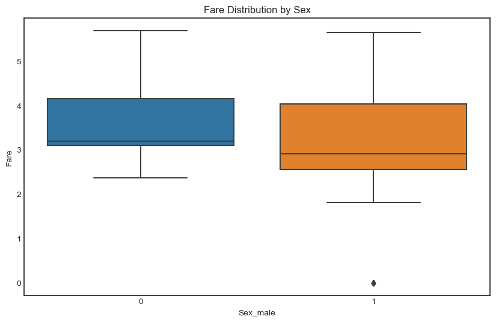

```python
plt.figure(figsize=(10, 6))
sns.boxplot(x='Pclass', y='Age', data=encoded_df)
plt.title('Age Distribution by Pclass')
plt.show()

plt.figure(figsize=(10, 6))
sns.boxplot(x='Sex_male', y='Fare', data=encoded_df)
plt.title('Fare Distribution by Sex')
plt.show()
```

##### 6. Distribution Plots: Visualize the distribution of numerical features with KDE plots.

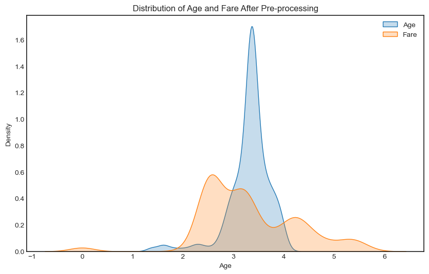

```python
plt.figure(figsize=(10, 6))
sns.kdeplot(encoded_df['Age'], shade=True, label='Age')
sns.kdeplot(encoded_df['Fare'], shade=True, label='Fare')
plt.title('Distribution of Age and Fare After Pre-processing')
plt.legend()
plt.show()
```

#### g. Step 2: Apply appropriate feature engineering techniques for them. Apply the feature transformation techniques like Standardization, Normalization, etc.You are free to apply the appropriate transformations depending upon the structure and the complexity of your dataset. Provide proper justification.Explore few techniques for identifying feature importance for your feature engineering task

##### 1. Apply Feature Transformation techniques

```python
# Split the dataset into features and target
X = encoded_df.drop('Survived', axis=1)
y = encoded_df['Survived']
```

##### 2. Apply Polynomial Feature transformation:

Create polynomial features to capture non-linear relationships between features.

```python
# Apply Polynomial Features transformation
numerical_features=["Age","Fare"]
poly = PolynomialFeatures(degree=2, interaction_only=True, include_bias=False)
X_poly = poly.fit_transform(X[numerical_features])
```

```python
# Convert the transformed array back to a DataFrame
X_poly_df = pd.DataFrame(X_poly, columns=poly.get_feature_names(input_features=numerical_features))
```

##### 3. Apply Feature Scaling:

Scale features to have similar ranges to avoid dominance of certain features during modeling.

```python
# Apply Feature Scaling
scaler = StandardScaler()
X_scaled = scaler.fit_transform(X[numerical_features])
```

```python
# Convert the scaled array back to a DataFrame
X_scaled_df = pd.DataFrame(X_scaled, columns=numerical_features)
```

##### 4. Data Representation after Standardization

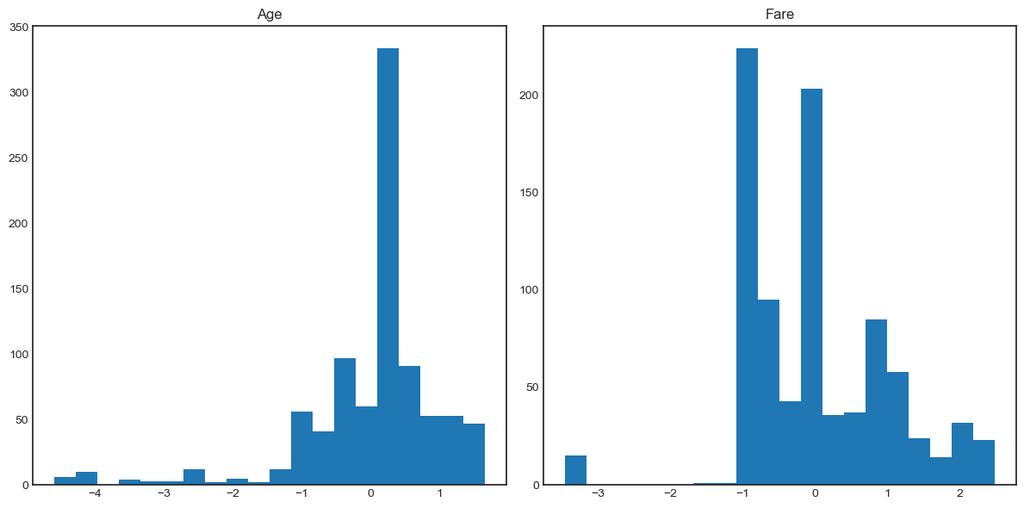

```python
# Plot histograms of scaled features
plt.figure(figsize=(12, 6))
for i, col in enumerate(X_scaled_df.columns):
    plt.subplot(1, len(X_scaled_df.columns), i + 1)
    plt.hist(X_scaled_df[col], bins=20)
    plt.title(col)
plt.tight_layout()
plt.show()
```

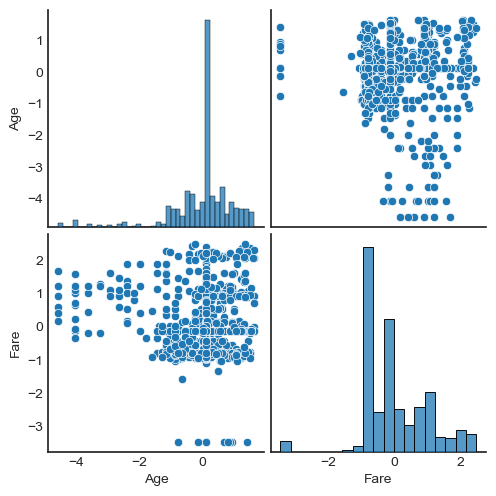

```python
sns.pairplot(X_scaled_df)
plt.show()
```

##### 5. Feature Importance

```python
# Create a RandomForestClassifier
model = RandomForestClassifier(random_state=42)

# Fit the model on the scaled data
model.fit(X_scaled, y)

# Get feature importances
feature_importances = model.feature_importances_

# Create a DataFrame to store feature names and their importance scores
feature_importance_df = pd.DataFrame({'Feature': X_scaled_df.columns, 'Importance': feature_importances})

# Sort the DataFrame by importance in descending order
feature_importance_df = feature_importance_df.sort_values(by='Importance', ascending=False)
feature_importance_df
```

|  | Feature | Importance |
| --- | --- | --- |
| 1 | Fare | 0.638411 |
| 0 | Age | 0.361589 |

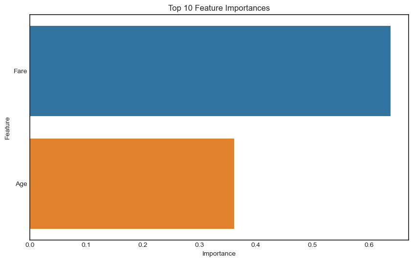

```python
# Plotting the top N features
plt.figure(figsize=(10, 6))
sns.barplot(x='Importance', y='Feature', data=feature_importance_df[:10])
plt.title('Top 10 Feature Importances')
plt.xlabel('Importance')
plt.ylabel('Feature')
plt.show()
```

### Section 4: Model Building

### Case 1:

#### Step 1: Split the dataset into training and test sets. Case 1: Train = 80 % Test = 20% [ x_train1,y_train1] = 80% ; [ x_test1,y_test1] = 20% ;

```python
# Split the dataset into training and test sets (80-20 split)
x_train1, x_test1, y_train1, y_test1 = train_test_split(X_scaled, y, test_size=0.2, random_state=42)
```

```python
# Perform 5-fold cross-validation
k = 5
scores = cross_val_score(model, X_scaled, y, cv=k)
```

```python
# Print the cross-validation scores
print("Cross-Validation Scores:", scores)

# Calculate and print the average cross-validation score
average_score = sum(scores) / k
print("Average Cross-Validation Score:", average_score)
```

```
Cross-Validation Scores: [0.5698324  0.67977528 0.62359551 0.64044944 0.61797753]
Average Cross-Validation Score: 0.6263260310087251
```

##### Step 2: Build Model/s using Logistic Regression

```python
# Create a Logistic Regression model
logreg_model = LogisticRegression(random_state=42)
```

```python
# Train the model on the training data
logreg_model.fit(x_train1, y_train1)
```

```
LogisticRegression(random_state=42)
```

```python
# Make predictions on the test data
y_pred = logreg_model.predict(x_test1)
```

```python
# Calculate accuracy
accuracy = accuracy_score(y_test1, y_pred)
accuracy
```

```
0.6145251396648045
```

```python
print(classification_report(y_test1,y_pred))
```

```
              precision    recall  f1-score   support

           0       0.62      0.90      0.73       105
           1       0.60      0.20      0.30        74

    accuracy                           0.61       179
   macro avg       0.61      0.55      0.52       179
weighted avg       0.61      0.61      0.56       179
```

##### Step 3: Explore the need of regularization and incorporate few relevant techniques for the problem statement.

##### a. L1 Regularization

```python
# Create a Logistic Regression model with L1 regularization
logreg_l1_model = LogisticRegression(penalty='l1', solver='liblinear', random_state=42)
```

```python
# Train the model on the training data
logreg_l1_model.fit(x_train1, y_train1)
```

```
LogisticRegression(penalty='l1', random_state=42, solver='liblinear')
```

```python
# Make predictions on the test data
y_pred_l1 = logreg_l1_model.predict(x_test1)
```

```python
# Calculate accuracy
accuracy_l1 = accuracy_score(y_test1, y_pred_l1)
print("Accuracy with L1 Regularization:", accuracy_l1)
```

```
Accuracy with L1 Regularization: 0.6145251396648045
```

```python
# Print classification report
print("Classification Report with L1 Regularization:")
print(classification_report(y_test1, y_pred_l1))
```

```
Classification Report with L1 Regularization:
              precision    recall  f1-score   support

           0       0.62      0.90      0.73       105
           1       0.60      0.20      0.30        74

    accuracy                           0.61       179
   macro avg       0.61      0.55      0.52       179
weighted avg       0.61      0.61      0.56       179
```

##### b. L2 Regularization

```python
# Create a Logistic Regression model with L2 regularization
logreg_l2_model = LogisticRegression(penalty='l2', random_state=42)
```

```python
# Train the model on the training data
logreg_l2_model.fit(x_train1, y_train1)
```

```
LogisticRegression(random_state=42)
```

```python
# Make predictions on the test data
y_pred_l2 = logreg_l2_model.predict(x_test1)
```

```python
# Calculate accuracy
accuracy_l2 = accuracy_score(y_test1, y_pred_l2)
print("Accuracy with L2 Regularization:", accuracy_l2)
```

```
Accuracy with L2 Regularization: 0.6145251396648045
```

```python
# Print classification report
print("Classification Report with L2 Regularization:")
print(classification_report(y_test1, y_pred_l2))
```

```
Classification Report with L2 Regularization:
              precision    recall  f1-score   support

           0       0.62      0.90      0.73       105
           1       0.60      0.20      0.30        74

    accuracy                           0.61       179
   macro avg       0.61      0.55      0.52       179
weighted avg       0.61      0.61      0.56       179
```

```python
data = {
    'Model': ['Without Regularization', 'L1 Regularization', 'L2 Regularization'],
    'Accuracy': [accuracy, accuracy_l1, accuracy_l2]
}
```

```python
comparison_df = pd.DataFrame(data)
comparison_df
```

|  | Model | Accuracy |
| --- | --- | --- |
| 0 | Without Regularization | 0.614525 |
| 1 | L1 Regularization | 0.614525 |
| 2 | L2 Regularization | 0.614525 |

### Case 2:

#### Step 1: Use different train and test data

```python
test_df = pd.read_csv('../data/test.csv')
```

##### Step 2: Perform Pre processing of the test data

```python
# Identify missing values
test_df.isnull().sum()
```

```
PassengerId      0
Pclass           0
Name             0
Sex              0
Age             86
SibSp            0
Parch            0
Ticket           0
Fare             1
Cabin          327
Embarked         0
dtype: int64
```

```python
# Fill missing age with median values
median_age = test_df['Age'].median()
test_df["Age"].fillna(median_age,inplace=True)
```

```python
test_df.isnull().sum()
```

```
PassengerId      0
Pclass           0
Name             0
Sex              0
Age              0
SibSp            0
Parch            0
Ticket           0
Fare             1
Cabin          327
Embarked         0
dtype: int64
```

```python
# Drop cabin column due to large number of missing values
test_df.drop(columns=['Cabin'], inplace=True)
test_df
```

|  | PassengerId | Pclass | Name | Sex | Age | SibSp | Parch | Ticket | Fare | Embarked |
| --- | --- | --- | --- | --- | --- | --- | --- | --- | --- | --- |
| 0 | 892 | 3 | Kelly, Mr. James | male | 34.5 | 0 | 0 | 330911 | 7.8292 | Q |
| 1 | 893 | 3 | Wilkes, Mrs. James (Ellen Needs) | female | 47.0 | 1 | 0 | 363272 | 7.0000 | S |
| 2 | 894 | 2 | Myles, Mr. Thomas Francis | male | 62.0 | 0 | 0 | 240276 | 9.6875 | Q |
| 3 | 895 | 3 | Wirz, Mr. Albert | male | 27.0 | 0 | 0 | 315154 | 8.6625 | S |
| 4 | 896 | 3 | Hirvonen, Mrs. Alexander (Helga E Lindqvist) | female | 22.0 | 1 | 1 | 3101298 | 12.2875 | S |
| ... | ... | ... | ... | ... | ... | ... | ... | ... | ... | ... |
| 413 | 1305 | 3 | Spector, Mr. Woolf | male | 27.0 | 0 | 0 | A.5. 3236 | 8.0500 | S |
| 414 | 1306 | 1 | Oliva y Ocana, Dona. Fermina | female | 39.0 | 0 | 0 | PC 17758 | 108.9000 | C |
| 415 | 1307 | 3 | Saether, Mr. Simon Sivertsen | male | 38.5 | 0 | 0 | SOTON/O.Q. 3101262 | 7.2500 | S |
| 416 | 1308 | 3 | Ware, Mr. Frederick | male | 27.0 | 0 | 0 | 359309 | 8.0500 | S |
| 417 | 1309 | 3 | Peter, Master. Michael J | male | 27.0 | 1 | 1 | 2668 | 22.3583 | C |

418 rows × 10 columns

```python
# Handling outliers
# Calculate IQR for 'Age' and 'Fare'
Q1 = test_df[['Age', 'Fare']].quantile(0.20)
Q3 = test_df[['Age', 'Fare']].quantile(0.85)
IQR = Q3 - Q1
```

```python
# Define lower and upper bounds for outlier detection
lower_bound = Q1 - 1.5 * IQR
upper_bound = Q3 + 1.5 * IQR
```

```python
# Replace outliers with NaN in 'Age' column
test_df['Age'] = np.where((test_df['Age'] < lower_bound['Age']) | (test_df['Age'] > upper_bound['Age']),
                          np.nan, test_df['Age'])
```

```python
# Replace outliers with NaN in 'Fare' column
test_df['Fare'] = np.where((test_df['Fare'] < lower_bound['Fare']) | (test_df['Fare'] > upper_bound['Fare']),
                           np.nan, test_df['Fare'])
```

```python
# Handle missing values in 'Age' column using median
median_age = test_df['Age'].median()
test_df['Age'].fillna(median_age, inplace=True)
```

```python
# Handle missing values in 'Fare' column using median
median_fare = test_df['Fare'].median()
test_df['Fare'].fillna(median_fare, inplace=True)
```

```python
# Handling skewness in the data
# Apply Box-Cox transformation to 'Fare' column
test_df['Fare'] = test_df['Fare'].apply(lambda x: x + 1)  # Adding 1 to handle zero values
test_df['Fare'], _ = boxcox(test_df['Fare']) # Applying Box-Cox transformation
```

```python
# Apply log transformation to 'Age' column
test_df['Age'] = np.log1p(test_df['Age'])
```

```python
# Perform One-Hot Encoding for 'Sex' and 'Embarked' columns
encoded_test_df = pd.get_dummies(test_df, columns=['Sex', 'Embarked'], drop_first=True)
encoded_test_df
```

|  | PassengerId | Pclass | Name | Age | SibSp | Parch | Ticket | Fare | Sex_male | Embarked_Q | Embarked_S |
| --- | --- | --- | --- | --- | --- | --- | --- | --- | --- | --- | --- |
| 0 | 892 | 3 | Kelly, Mr. James | 3.569533 | 0 | 0 | 330911 | 1.754480 | 1 | 1 | 0 |
| 1 | 893 | 3 | Wilkes, Mrs. James (Ellen Needs) | 3.871201 | 1 | 0 | 363272 | 1.690909 | 0 | 0 | 1 |
| 2 | 894 | 2 | Myles, Mr. Thomas Francis | 4.143135 | 0 | 0 | 240276 | 1.873986 | 1 | 1 | 0 |
| 3 | 895 | 3 | Wirz, Mr. Albert | 3.332205 | 0 | 0 | 315154 | 1.811494 | 1 | 0 | 1 |
| 4 | 896 | 3 | Hirvonen, Mrs. Alexander (Helga E Lindqvist) | 3.135494 | 1 | 1 | 3101298 | 2.004599 | 0 | 0 | 1 |
| ... | ... | ... | ... | ... | ... | ... | ... | ... | ... | ... | ... |
| 413 | 1305 | 3 | Spector, Mr. Woolf | 3.332205 | 0 | 0 | A.5. 3236 | 1.770201 | 1 | 0 | 1 |
| 414 | 1306 | 1 | Oliva y Ocana, Dona. Fermina | 3.688879 | 0 | 0 | PC 17758 | 3.008927 | 0 | 0 | 0 |
| 415 | 1307 | 3 | Saether, Mr. Simon Sivertsen | 3.676301 | 0 | 0 | SOTON/O.Q. 3101262 | 1.710883 | 1 | 0 | 1 |
| 416 | 1308 | 3 | Ware, Mr. Frederick | 3.332205 | 0 | 0 | 359309 | 1.770201 | 1 | 0 | 1 |
| 417 | 1309 | 3 | Peter, Master. Michael J | 3.332205 | 1 | 1 | 2668 | 2.316913 | 1 | 0 | 0 |

418 rows × 11 columns

```python
# Split the dataset into features and target
X_test = encoded_test_df

print(x_train1.shape)
print(y_train1.shape)
print(X_test.shape)
```

```
(712, 2)
(712,)
(418, 11)
```

```python
# Apply Polynomial Features transformation
numerical_features=["Age","Fare"]
poly = PolynomialFeatures(degree=2, interaction_only=True, include_bias=False)
X_test_poly = poly.fit_transform(X_test[numerical_features])
```

```python
# Convert the transformed array back to a DataFrame
X_test_poly_df = pd.DataFrame(X_test_poly, columns=poly.get_feature_names(input_features=numerical_features))
```

```python
# Apply Feature Scaling
scaler = StandardScaler()
X_test_scaled = scaler.fit_transform(X_test[numerical_features])
```

```python
# Convert the scaled array back to a DataFrame
X_test_scaled_df = pd.DataFrame(X_test_scaled, columns=numerical_features)
```

##### Step 3: Build Models using logistic regression

```python
# Create a Logistic Regression model without regularization
logreg_model = LogisticRegression(random_state=42)
logreg_model.fit(x_train1, y_train1)  # Use the entire dataset for training
```

```
LogisticRegression(random_state=42)
```

```python
# Make predictions on the new test data
y_pred_test = logreg_model.predict(X_test_scaled)
```

```python
# Create a DataFrame to hold the predictions
predictions_df = pd.DataFrame({'PassengerId': test_df['PassengerId'], 'Survived': y_pred_test})
```

##### Step 4: Build Model using RandomForestClassifier

```python
random_forest_model = RandomForestClassifier(random_state=42)
random_forest_model.fit(x_train1, y_train1)
```

```
RandomForestClassifier(random_state=42)
```

```python
# Make predictions on the new test data
y_pred_rf = random_forest_model.predict(X_test_scaled)
```

```python
# Create a DataFrame to hold the predictions
predictions_df = pd.DataFrame({'PassengerId': test_df['PassengerId'], 'Survived': y_pred_rf})
```

##### Step 5: Build model using Gradient Boosting

```python
gradient_boosting_model = GradientBoostingClassifier(random_state=42)
gradient_boosting_model.fit(x_train1, y_train1)
```

```
GradientBoostingClassifier(random_state=42)
```

```python
y_pred_gb = gradient_boosting_model.predict(X_test_scaled)
```

```python
# Create a DataFrame to hold the predictions
predictions_df = pd.DataFrame({'PassengerId': test_df['PassengerId'], 'Survived': y_pred_gb})
```

##### Step 6: Build Model with hyper parameter tuning for logistic regression

```python
logreg_param_grid = {'C': [0.001, 0.01, 0.1, 1, 10, 100]}
logreg_grid_search = GridSearchCV(LogisticRegression(random_state=42), logreg_param_grid, cv=5)
logreg_grid_search.fit(x_train1, y_train1)
best_logreg_model = logreg_grid_search.best_estimator_
```

```python
y_pred_logreg = best_logreg_model.predict(X_test_scaled)
```

```python
# Create a DataFrame to hold the predictions
predictions_df = pd.DataFrame({'PassengerId': test_df['PassengerId'], 'Survived': y_pred_logreg})
```

##### Step 7: Build Model with hyper parameter tuning for Random Forest Classifier

```python
# Hyperparameter tuning for Random Forest
rf_param_grid = {'n_estimators': [100, 200, 300],
                 'max_depth': [None, 10, 20],
                 'min_samples_split': [2, 5, 10],
                 'min_samples_leaf': [1, 2, 4]}
rf_grid_search = GridSearchCV(RandomForestClassifier(random_state=42), rf_param_grid, cv=5)
rf_grid_search.fit(x_train1, y_train1)
best_rf_model = rf_grid_search.best_estimator_
```

```python
y_pred_rf = best_rf_model.predict(X_test_scaled)
```

```python
# Create a DataFrame to hold the predictions
predictions_df = pd.DataFrame({'PassengerId': test_df['PassengerId'], 'Survived': y_pred_rf})
```

```python
predictions_df.to_csv('predictions.csv',index=False)
```